# germlinevaR walkthrough

Thiago Loreto Matos and Felipe Pantoja Mesquita

Pharmacogenetics Laboratory, Drug Research and Development Center, Department of Physiology and Pharmacology, Federal University of Ceará, Fortaleza, 60430-160, Brazil

thiago-loreto@hotmail.com  
felipemesquita05@gmail.com

2026-06-26

#### Package

germlinevaR 0.99.0

# 1 Introduction

**germlinevaR** is a self-contained R toolchain for single-sample germline VCFs annotated with Ensembl VEP, SnpEff, or both. It turns on-disk VCFs into an MAF-like `data.table`, filters them with a modular set of toggles, isolates candidate novel variants, summarises a cohort, and renders publication-ready per-gene plots — all inside one R session, without an external pipeline.

## 1.1 Motivation for Bioconductor

Germline variant analysis sits at the intersection of clinical genetics and bioinformatics: researchers need to go from annotated VCFs to filtered, interpretable variant tables and publication-ready figures without stitching together multiple unrelated tools. germlinevaR fills this gap by providing a single, cohesive workflow that handles the full journey from VCF to cohort summary and per-gene visualisation, with built-in support for the two most widely used annotators (Ensembl VEP and SnpEff) and optional Brazilian population frequency annotation (ABraOM SABE-609). Inclusion in Bioconductor makes the package discoverable to the clinical genomics community and ensures long-term maintenance through the Bioconductor release cycle.

## 1.2 Comparison with related packages

Several Bioconductor and CRAN packages address parts of the germline variant analysis workflow:

- **`VariantAnnotation`** (Bioconductor): provides low-level VCF parsing and annotation infrastructure. germlinevaR builds on top of this conceptual layer but targets a higher-level workflow: it reads VEP/SnpEff-annotated VCFs directly, applies opinionated filtering, and produces cohort summaries and plots without requiring users to manipulate `VCF` or `GRanges` objects.
- **`maftools`** (Bioconductor): a comprehensive somatic mutation analysis toolkit centred on the MAF format. germlinevaR is complementary: it targets the **germline** single-sample case, produces an MAF-like table for compatibility, and adds VEP/SnpEff multi-annotator support and population-frequency filtering that maftools does not provide.
- **`vcfR`** (CRAN): focuses on VCF import and manipulation. germlinevaR goes further downstream: after reading the VCF it applies clinical-significance and population-frequency filters, generates a cohort summary, and renders per-gene lollipop plots.

germlinevaR’s unique combination is the auto-routing multi-annotator reader + modular clinical filter + cohort summary + per-gene visualisation, all in one package with no external pipeline dependency.

## 1.3 Vignette scope

This vignette walks through the package on the **tiny example VCF shipped with the package**: a single anonymised sample with 62 variants covering all 17 VEP `Variant_Classification` levels, drawn from a real exome to keep the example faithful. The whole walkthrough runs in a few seconds.

What this vignette does **not** cover: variant calling, VCF annotation (do it upstream with VEP or SnpEff), and somatic tumour/normal pipelines. germlinevaR is built for germline single-sample analyses.

# 2 Installation

```r
if (!requireNamespace("BiocManager", quietly = TRUE))
    install.packages("BiocManager")

BiocManager::install("germlinevaR")
```

For the development version from GitHub:

```r
# install.packages("remotes")
remotes::install_github("FarmagenUFC/germlinevaR")
```

# 3 Quick start

```r
library(germlinevaR)
library(data.table)
```

# 4 Reading a VCF into an MAF-like table

`read.gvr()` is the auto-routing entry point: it inspects the VCF header, detects whether annotations come from VEP, SnpEff, or both, and dispatches to the correct sibling reader (`read.gvr`, `read.gvr.snpeff`, or `read.gvr.dual`). When you read your own data, point `read.gvr()` at the folder containing your VCF file(s) — the function discovers every `*.vcf.gz` in that directory, auto-detects the annotator on each file, and returns one MAF-like row per ALT allele. All files in a batch must share the same annotator; mixed VEP/SnpEff folders are rejected. For this vignette we stage the shipped example into a temporary directory and read it from there:

```r
vcf_dir <- tempfile("gvr_vig_")
dir.create(vcf_dir)
file.copy(
  system.file("extdata", "example.vep.vcf.gz", package = "germlinevaR"),
  file.path(vcf_dir, "example.vep.vcf.gz")
)
```

```
#> [1] TRUE
```

```r
gvr <- read.gvr(vcf_dir, verbose = FALSE)
dim(gvr)
```

```
#> [1]  62 116
```

The returned `data.table` carries one row per ALT allele on the most-severe transcript, with a canonical 116-column schema:

```r
head(gvr[, .(Hugo_Symbol, Variant_Classification, IMPACT,
             Tumor_Sample_Barcode)])
```

```
#>    Hugo_Symbol Variant_Classification   IMPACT Tumor_Sample_Barcode
#>         <char>                 <char>   <char>               <char>
#> 1:       OR4F5                 Silent      LOW            Sample_01
#> 2:       OR4F5      Missense_Mutation MODERATE            Sample_01
#> 3:       OR4F5                 Silent      LOW            Sample_01
#> 4:     Unknown                 Intron MODIFIER            Sample_01
#> 5:      WASH9P                    RNA MODIFIER            Sample_01
#> 6:      SAMD11                  5'UTR MODIFIER            Sample_01
```

# 5 Filtering: `gvr_filter()`

`gvr_filter()` exposes population-frequency, clinical-significance, biotype, variant-classification, genotype, and panel filters as independent toggles. Defaults drop variants common in gnomAD exomes, 1000 Genomes, or ABraOM (above 1 %), and require either a pathogenic ClinVar annotation or no annotation at all:

```r
filt <- gvr_filter(gvr, verbose = FALSE)
dim(filt)
```

```
#> [1]   7 116
```

```r
table(filt$Variant_Classification)
```

```
#>
#>        Frame_Shift_Del        Frame_Shift_Ins                 Intron
#>                      1                      1                      1
#>      Missense_Mutation       Nonstop_Mutation            Splice_Site
#>                      1                      1                      1
#> Translation_Start_Site
#>                      1
```

Defaults take the 62-row example down to 7 rows, one per surviving variant classification. To restrict to a curated gene panel, pass `genes =`:

```r
gvr_list_panels()                    # registered panels
```

```
#>  [1] "acromegaly"
#>  [2] "breast cancer"
#>  [3] "breast cancer somatic"
#>  [4] "familial adenomatous polyposis"
#>  [5] "gist"
#>  [6] "hereditary breast and ovarian cancer"
#>  [7] "hereditary cancer"
#>  [8] "hereditary colorectal cancer"
#>  [9] "hereditary gastric cancer"
#> [10] "hereditary melanoma cancer"
#> [11] "hereditary prostate cancer"
#> [12] "li-fraumeni syndrome"
#> [13] "lynch syndrome"
#> [14] "men1"
#> [15] "pheochromocytoma"
```

```r
panel <- gvr_panel_genes("breast cancer")
panel
```

```
#>  [1] "AKT1"   "ATM"    "BARD1"  "BRCA1"  "BRCA2"  "BRIP1"  "CDH1"   "CHEK2"
#>  [9] "EPCAM"  "ERBB2"  "ESR1"   "MLH1"   "MSH2"   "MSH6"   "NBN"    "NF1"
#> [17] "PALB2"  "PIK3CA" "PMS2"   "PTEN"   "RAD51C" "RAD51D" "STK11"  "TP53"
```

```r
filt_bc <- gvr_filter(gvr, genes = panel, verbose = FALSE)
filt_bc[, .(Hugo_Symbol, HGVSp_Short, Variant_Classification, IMPACT)]
```

```
#>    Hugo_Symbol HGVSp_Short Variant_Classification   IMPACT
#>         <char>      <char>                 <char>   <char>
#> 1:       BRCA2    p.G1376A      Missense_Mutation MODERATE
```

The one BC-panel survivor — BRCA2 p.G1376A — is a missense with no rsID and no allele frequency in any catalogue, which is exactly the profile that motivates the next section.

# 6 Candidate novel variants: `gvr_novel()`

`gvr_novel()` is a dedicated subsetter that returns rows with no dbSNP rsID **and** no allele frequency in gnomAD, 1000 Genomes, or ABraOM. These are the variants most worth following up:

```r
novel <- gvr_novel(gvr, verbose = FALSE)
dim(novel)
```

```
#> [1]   3 116
```

```r
novel[, .(Hugo_Symbol, HGVSp_Short, Variant_Classification, IMPACT)]
```

```
#>    Hugo_Symbol HGVSp_Short Variant_Classification   IMPACT
#>         <char>      <char>                 <char>   <char>
#> 1:      ATAD3B                             Intron MODIFIER
#> 2:    C11orf21                        Splice_Site     HIGH
#> 3:       BRCA2    p.G1376A      Missense_Mutation MODERATE
```

Note that the BRCA2 p.G1376A row from the panel filter above also appears here — a single variant can satisfy several criteria at once.

# 7 Cohort summary: `gvr_summary()`

`gvr_summary()` returns an 8-section list-of-`data.table`s ready for direct inspection or downstream tabulation. It can also write the same content as an Excel workbook, a multi-page PDF, and a self-contained interactive HTML dashboard with plotly drill-downs and DT tables; we disable those side effects here to keep the vignette fast:

```r
summ <- gvr_summary(
  gvr,
  save_excel = FALSE, save_pdf = FALSE, save_html = FALSE,
  verbose    = FALSE
)
names(summ)
```

```
#> [1] "overview"               "top_genes"              "top_genes_per_sample"
#> [4] "variant_classification" "variant_type"           "clin_sig"
#> [7] "impact"                 "top_variants"
```

```r
summ$top_genes
```

```
#>     Hugo_Symbol Sample_01 Total
#>          <char>     <int> <num>
#>  1:       OR4F5         3     3
#>  2:      ACTRT2         1     1
#>  3:     ARHGEF7         1     1
#>  4:      ATAD3A         1     1
#>  5:      ATAD3B         1     1
#>  6:    ATP6V1B1         1     1
#>  7:       ATRIP         1     1
#>  8:       BRCA1         1     1
#>  9:       BRCA2         1     1
#> 10:        BRD7         1     1
#> 11:    C11orf21         1     1
#> 12:    C1QTNF12         1     1
#> 13:         CA6         1     1
#> 14:      CACHD1         1     1
#> 15:       CCNL2         1     1
#> 16:        CD1C         1     1
#> 17:      COL5A1         1     1
#> 18:    CSNKA2IP         1     1
#> 19:        EFL1         1     1
#> 20:        ESPN         1     1
#>     Hugo_Symbol Sample_01 Total
```

For the full HTML dashboard call `gvr_summary(..., save_html = TRUE, out_dir = ".")`.

# 8 Static plots

**Protein-domain lollipop** — `gvr_lollipop(gvr, gene = "TP53")` draws variants along the protein, with InterPro domains fetched and cached on the fly:

[figure not shown]

Figure 1: Lollipop for TP53 from gvr_lollipop() — InterPro domains shaded

**Gene-structure lollipop** — `gvr_genepos.plot(gvr, gene = "BRCA1")` draws variants along the gene’s cDNA, with exon/intron/UTR regions resolved via Ensembl REST or a local GTF:

[figure not shown]

Figure 2: Gene-structure track for BRCA1 from gvr_genepos.plot() — exons/UTRs from Ensembl REST

**Top-genes variant matrix** — `gvr_plot(gvr, top_n = 20, out_dir = ".")` writes a `ComplexHeatmap` top-genes variant matrix PNG of the top mutated genes across samples, coloured by the most severe variant class per cell. The top bar shows per-sample variant impact (HIGH / MODERATE / LOW / MODIFIER); the right bar shows per-gene total burden. The figure below uses illustrative multi-sample data to demonstrate the layout:

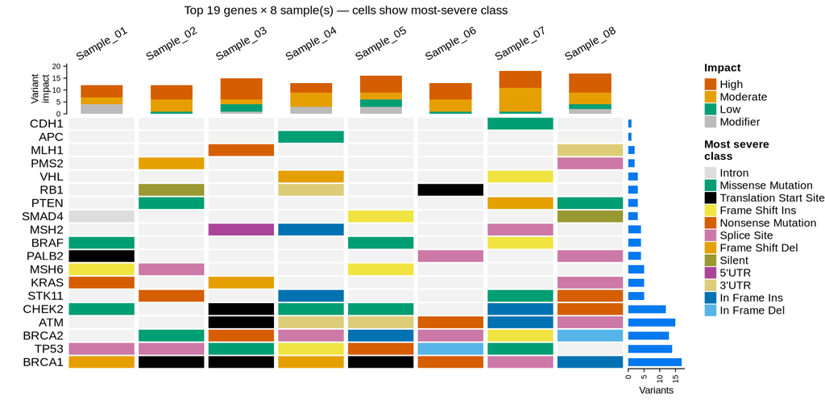

`gvr_sum_plots()` writes the same panels that `gvr_summary(save_html = TRUE)` embeds in its interactive dashboard (top genes, variant classification, IMPACT, top variants) as standalone PNGs.

# 9 Where to next

- `?read.gvr` — every reader option (parallel cohort folders, ABraOM joining, custom output paths)
- `?gvr_filter` — full toggle reference for each filter axis
- `?gvr_summary` — multi-section cohort summary with optional Excel, PDF, and HTML outputs
- `?gvr_lollipop` and `?gvr_genepos.plot` — per-gene plotting
- GitHub: https://github.com/FarmagenUFC/germlinevaR